# STAT 184 Homework Exercises

DataComputing Chapters 11

Isha Thukral

## Assigned Exercises

- DC Chapter 11 Exercises: 11.2, 11.3, 11.5, 11.6

## Front Matter

```r
# clean up workspace environment
rm(list = ls())

# all packages used for the assignment
library(mosaic)
library(tidyverse)
library(mosaicData)
library(esquisse)
library(dcData)
```

## Chapter 11 Exercises

### Problem 11.2

To join the two tables, there must be a common column between the tables. At first, I thought we could combine the ‘country’ and ‘name’ columns, but they have a different number of rows. And finally, if we were to copy and paste the long and lat numbers directly, they wouldn’t match the country names. For example, in table one, the countries are Afghanistan, Akrotiri, etc., while table 2 is- Afghanistan, Aland, etc.

### Problem 11.3

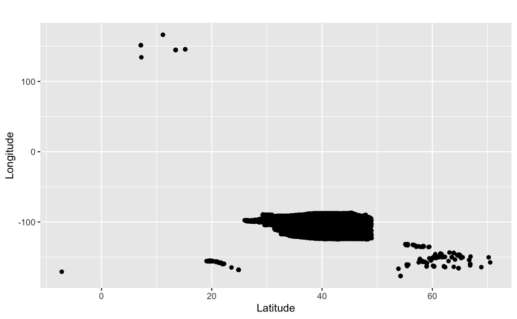

```r
crowdedZip <-
  ZipGeography %>%
  group_by(State,CityName) %>%
  filter(ZIP > 50000) %>%
  mutate(ZIP = ifelse(ZIP > 50000, "crowded", ZIP))

ggplot(data = crowdedZip, aes(x = Latitude, y = Longitude)) + geom_point()  + labs(title = "")
```

```r
allzips <-
  full_join(ZipDemography, ZipGeography, by = c("ZIP"="ZIP")) %>%
  group_by(State) %>%
  summarise(State = State, Fractionover65 = X65yearsandover/Totalpopulation) %>%
  filter(is.na(Fractionover65) == FALSE)
```

```
Mapping API still under development and may change in future releases.
```

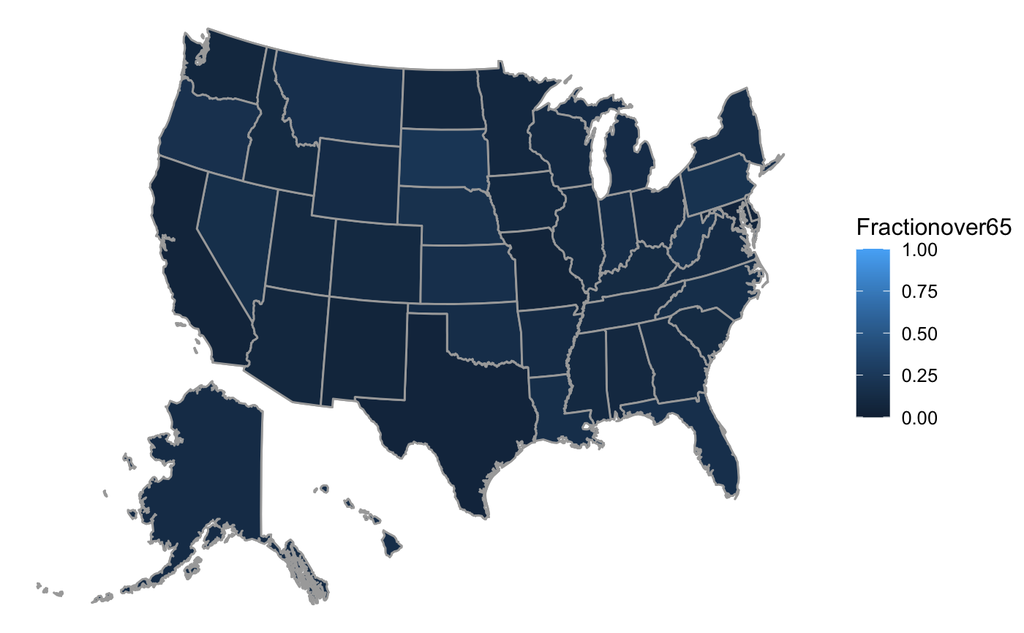

```r
mUSMap(allzips, key = "State", fill = "Fractionover65")
```

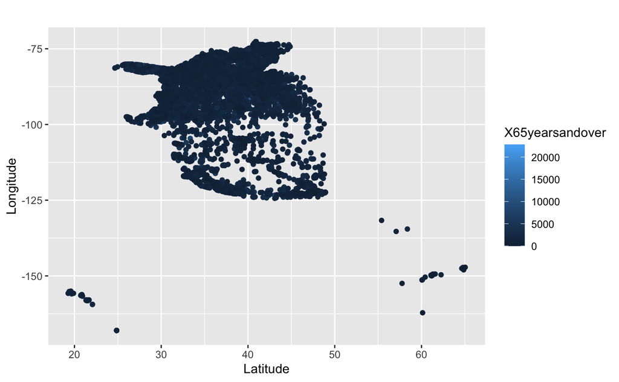

```r
ZipDemoGeo <-
  full_join(ZipDemography, ZipGeography, by = c("ZIP"="ZIP")) %>%
  select(Totalpopulation,X65yearsandover,Latitude,Longitude,ZIP) %>%
  filter(is.na(X65yearsandover) == FALSE & is.na(Latitude) == FALSE & is.na(Longitude) == FALSE & is.na(ZIP) == FALSE & is.na(Totalpopulation) == FALSE) %>%
  arrange(desc(Totalpopulation)) %>%
  head(10000)


ggplot(data = ZipDemoGeo, aes(x = Latitude, y = Longitude)) + geom_point()  + aes(colour = X65yearsandover) + theme(legend.position = "right") + labs(title = "")
```

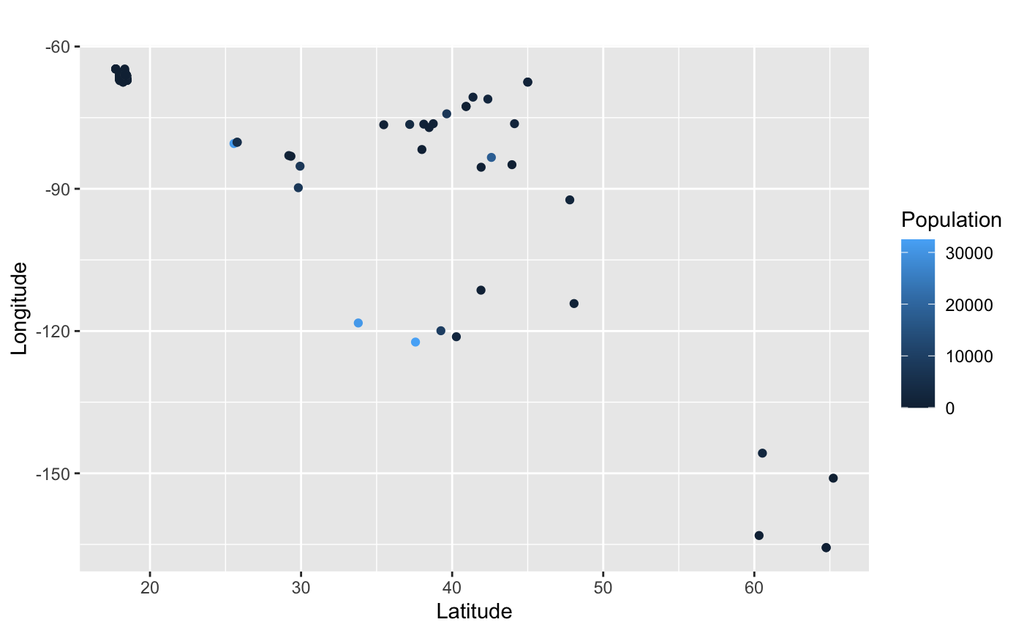

```r
LandWater <-
  ZipGeography %>%
  mutate(waterlandpercentage = WaterArea/(0.5 * LandArea)) %>%
  filter(waterlandpercentage>1)

ggplot(data = LandWater, aes(x = Latitude, y = Longitude)) + geom_point()  + aes(colour = Population) + theme(legend.position = "right") + labs(title = "")
```

### Problem 11.5

```r
n_distinct(ZipGeography %>%
  select(County))
```

```
[1] 1910
```

There are 1910 different counties.

```r
ZipGeography %>%
  group_by(CityName) %>%
  filter(is.na(CityName) == FALSE) %>%
  summarise(total = n()) %>%
  arrange(desc(total))
```

| CityName | total |
| --- | --- |
| Washington | 297 |
|  | 193 |
| Houston | 190 |
| New York | 162 |
| El Paso | 158 |
| Dallas | 128 |
| Atlanta | 113 |
| Springfield | 109 |
| Sacramento | 108 |
| Miami | 103 |

[output cut: 990 more lines]

```r
StatePopulation <-
  ZipGeography %>%
  filter(State != "" &is.na(Population) == FALSE) %>%
  group_by(State) %>%
  summarise(total = sum(Population))

CityPopulation <-
  ZipGeography %>%
  filter(State != "" &is.na(Population) == FALSE) %>%
  group_by(State, CityName) %>%
  summarise(Population = sum(Population), count = 1)
CityPopulation %>%
  left_join(StatePopulation,by = c("State" = "State")) %>%
  mutate(percentPop = Population/total) %>%
  filter(percentPop > 0.05) %>%
  group_by(CityName) %>%
  summarise(n = sum(count)) %>%
  arrange(desc(n))
```

| CityName | n |
| --- | --- |
| Kansas City | 2 |
| Boston | 1 |
| Burlington | 1 |
| Cranston | 1 |
| Dover | 1 |
| Glendale | 1 |
| Lexington | 1 |
| Lincoln | 1 |
| Littleton | 1 |
| Manchester | 1 |

[output cut: 99 more lines]

For cities with 5% of population of their state, Kansas City is used the most.

```r
ZipGeography %>%
  select(State, Timezone) %>%
  filter(State != "" &is.na(Timezone) == FALSE & Timezone != " ") %>%
  distinct(State, Timezone) %>%
  group_by(State) %>%
  summarise(total = n()) %>%
  filter(total > 1)
```

| State | total |
| --- | --- |
| Florida | 2 |
| Tennessee | 2 |
| Kentucky | 2 |
| Indiana | 2 |
| Michigan | 2 |
| North Dakota | 2 |
| South Dakota | 2 |
| Kansas | 2 |
| Nebraska | 2 |
| Texas | 2 |

[output cut: 4 more lines]

The following 14 states have more than one timezone.

```r
ZipGeography %>%
  select(CityName, Timezone) %>%
  filter(CityName != "" &is.na(Timezone) == FALSE & Timezone != "") %>%
  distinct(CityName, Timezone) %>%
  group_by(CityName) %>%
  summarise(total = n()) %>%
  arrange(desc(total))
```

| CityName | total |
| --- | --- |
| Hope | 5 |
| Beaver | 5 |
| Marshall | 5 |
| Albion | 4 |
| Arlington | 4 |
| Ashland | 4 |
| Auburn | 4 |
| Burlington | 4 |
| Centerville | 4 |
| Chester | 4 |

[output cut: 990 more lines]

The following citynames have more than one timezones.

```r
ZipGeography %>%
  select(County, Timezone) %>%
  filter(County != "" &is.na(Timezone) == FALSE & Timezone != "") %>%
  distinct(County, Timezone) %>%
  group_by(County) %>%
  summarise(total = n()) %>%
  arrange(desc(total))
```

| County | total |
| --- | --- |
| Franklin | 5 |
| Washington | 5 |
| Lincoln | 5 |
| Jefferson | 5 |
| Grant | 5 |
| Orange | 4 |
| Union | 4 |
| Columbia | 4 |
| Lewis | 4 |
| Adams | 4 |

[output cut: 990 more lines]

The following counties have more than one timezone.

### Problem 11.6

1. By using a MirgationFlows we can create a data frame that uses rename() function with arguments such as orgincode = countryB (or something similar) to make a table with same values as MigrationFlows but with different variable names.
2. For the join countryB is matched to origincode.
3. InfantA is being matched to countryA variable in MigrationFlows to iso_a3 to HealthIndicators get the infant mortality rate for countryA.
4. InfantB is being matched to countryB variable in MigrationFlows to iso_a3 to HealthIndicators get the infant mortality rate for countryB.